# Retrieve tissue-specifc miRNA data

Yining Ding

# Objective

The objective of this notebook is to retrieve miRNA expression data from various tissues, and processing them to extract the tissue-specific miRNA expression tables. The general workflow are 1) get data, 2) select normal or disease example accordingly, 3) select negative control group, 4) get threshold of the negative control group, 5) define human miRNA expression with that threshold, 6) finally, separate known and novel miRNA and save them into different files.

# Note

This notebook uses helper file /get_data_mir_expr/agilent_workflow_helper.R. The helper file also prints some information that can help us make some alternative decision.

# Library

The libraries used in this notebook are

- limma (Ritchie et al. 2015)
- ggplot2 (Kassambara 2020)
- miRNAmeConverter (Haunsberger, Connolly, and Prehn 2016)

# Download GSE28954

I chose to download GSE28954 (Cooley et al. 2012) data from EBI as the arrayexpress provides a better view.

```r
URL <- "https://www.ebi.ac.uk/arrayexpress/files/E-GEOD-28954"
SDRF.file <- "E-GEOD-28954.sdrf.txt"
Data.file <- "E-GEOD-28954.raw.1.zip"
if (! file.exists(SDRF.file)){
  download.file(paste(URL,SDRF.file,sep="/"), SDRF.file)
}
if (! file.exists(Data.file)){
  download.file(paste(URL,Data.file,sep="/"), Data.file)
  unzip(Data.file)
}
```

# Select only the normal samples

- Samples selected according to the EBI array data view. We can get an overview of the data from the array express.

```r
SDRF <- read.delim(SDRF.file,check.names=FALSE,stringsAsFactors=FALSE)
all_sample <- SDRF[,c("Array Data File","FactorValue [DISEASE]")]

kable(head(all_sample), caption = "Overview of the data", format="html") %>%
  kable_styling(bootstrap_options = c("stripe", "hover"))
```

Overview of the data

| Array Data File | FactorValue [DISEASE] |
| --- | --- |
| GSM717458_US80603148_252182712647_S01_miRNA_107_Sep09_2_4.txt | VHD |
| GSM717457_US80603148_252182712648_S01_miRNA_107_Sep09_1_4.txt | VHD |
| GSM717456_miRNA_252182712183_S01_miRNA_107_Sep09_2_2.txt | CABG |
| GSM717455_miRNA_252182712183_S01_miRNA_107_Sep09_1_4.txt | VHD |
| GSM717454_miRNA_252182712181_S01_miRNA_107_Sep09_2_4.txt | VHD |
| GSM717453_miRNA_252182712181_S01_miRNA_107_Sep09_1_4.txt | VHD |

```r
# get the ids of the selected samples
norm_ind <- which(SDRF$`FactorValue [DISEASE]` == "Healthy")
```

# Read data

```r
read_data <- read_data_by_limma(norm_ind)
```

```
Read GSM717436_miRNA_252182712181_S01_miRNA_107_Sep09_2_1.txt
Read GSM717435_miRNA_252182712181_S01_miRNA_107_Sep09_1_1.txt
Read GSM717434_miRNA_252182712181_S01_miRNA_107_Sep09_1_2.txt
Read GSM717433_miRNA_252182712183_S01_miRNA_107_Sep09_2_1.txt
Read GSM717432_miRNA_252182712183_S01_miRNA_107_Sep09_1_1.txt
```

```r
read_data <- data.frame(read_data)
read_data <- read_data[,-c(1, 2, 3, 4, 5, 6, 7, 8, 10)]
```

# Inspect plots before picking negative control group

We plot two graph for each tissue, the first one is only picking ngeative control and the second on is picking negative control with non-human miR. We wanted to examine which plot has a greater contrast. In all the tissues, we observe that the bar plots always sugguest us to pick the negative control only for the negative control group.

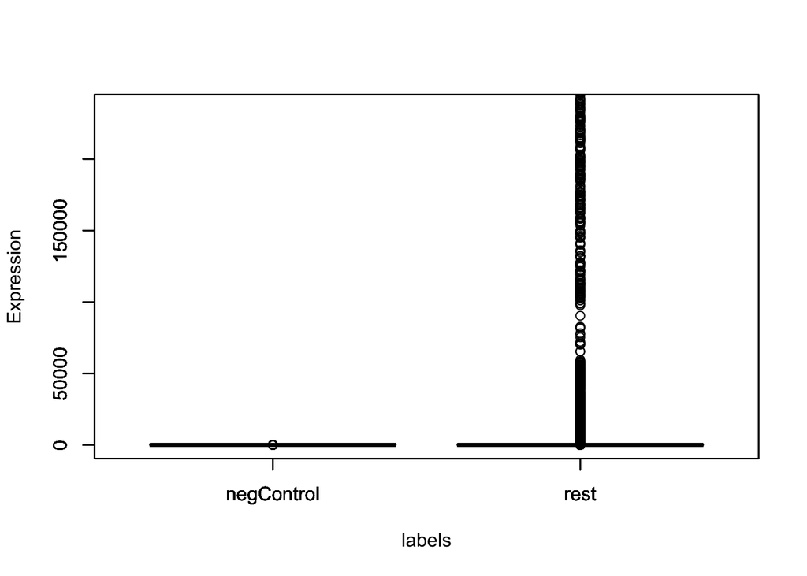

```r
plot_a <- plot_negctrl_vs_rest(read_data)
```

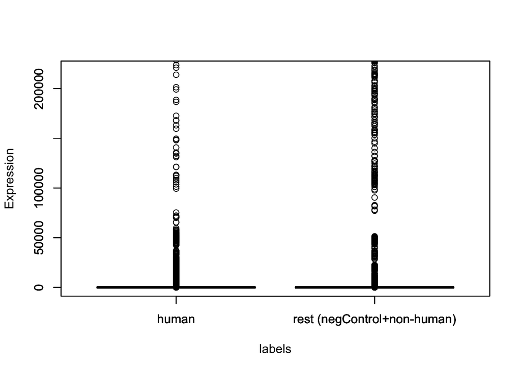

```r
plot_b <- plot_negctrl_plus_nonhuman_vs_rest(read_data)
```

# Extract human miR

Since we only focus on the expressivity of human miR.

```r
# find human miRNA
human <- grep(pattern="hsa", read_data$SystematicName)
human_miR <- read_data[human,]
```

# Data cleaning

- Find the number of human miR, corner removal report, inspect the result of the selection of the negative control group. (Whether the selection is biased or not.) The series will be discarded if the selected of the negative control group has a sample bias, i.e. selection are mostly from one sample

```r
neg_control <- data_cleaning(read_data)
```

```
number of hsa miRNAs:  15739
number of corners removed:  41
number of miR left after removal:  15698
number of negative control selected:  182
```

# Define expression

The human miR expression is defined by the lowest expressivity value from the negative control group. We also need to make sure that all the controls have expression value of 0.

```r
# threshold:
greatest_0.01 <- define_expression_threshold(y_neg_ctrl=neg_control, norm_ind=length(norm_ind))
```

```
number of negative control to select:  9
number of samples consistent:  TRUE
SD is 1.922094 in 5 samples
Threshold:  54
```

```r
# No bias, continue.
kable(head(table(greatest_0.01$position[,2])), caption = "Top 1% selection", format="html") %>%
  kable_styling(bootstrap_options = c("stripe", "hover"))
```

Top 1% selection

| Var1 | Freq |
| --- | --- |
| 1 | 3 |
| 2 | 1 |
| 4 | 1 |
| 5 | 4 |

```r
# define expressivity by threshold
defined <- define_miRNA_expression(human_miR_table=human_miR, thres=min(greatest_0.01$values))

# make sure that all controls have expression value = 0
if_ctrl_all_zero(human_miR_table=human_miR, copy_y=defined)
```

```
expression value of negative control are:  0
expression value of positive control are:  0
```

|  | miR | SUM | GSM717436_miRNA_252182712181_S01_miRNA_107_Sep09_2_1 | GSM717435_miRNA_252182712181_S01_miRNA_107_Sep09_1_1 | GSM717434_miRNA_252182712181_S01_miRNA_107_Sep09_1_2 | GSM717433_miRNA_252182712183_S01_miRNA_107_Sep09_2_1 | GSM717432_miRNA_252182712183_S01_miRNA_107_Sep09_1_1 |
| --- | --- | --- | --- | --- | --- | --- | --- |
| 1 | hsa-miR-720 | 5 | 1 | 1 | 1 | 1 | 1 |
| 2 | hsa-miR-587 | 0 | 0 | 0 | 0 | 0 | 0 |
| 3 | hsa-miR-1236 | 0 | 0 | 0 | 0 | 0 | 0 |
| 4 | hsa-miR-607 | 0 | 0 | 0 | 0 | 0 | 0 |
| 5 | hsa-miR-1253 | 0 | 0 | 0 | 0 | 0 | 0 |
| 6 | hsa-miR-369-3p | 0 | 0 | 0 | 0 | 0 | 0 |
| 7 | hsa-miR-657 | 0 | 0 | 0 | 0 | 0 | 0 |
| 8 | hsa-miR-526b | 0 | 0 | 0 | 0 | 0 | 0 |
| 9 | hsa-miR-515-3p | 0 | 0 | 0 | 0 | 0 | 0 |
| 10 | hsa-miR-586 | 0 | 0 | 0 | 0 | 0 | 0 |

[output cut: 990 more lines]

# Save final copies

We checked the names of the miR. The known and novel miRNA are separated and stored in different folders in **saved_expr_data/**. Final tables are all in the same format, miRNA sysmatic names, expression value, and the number of samples in this series.

```r
unique_all <- process_human_miR(defined, norm_ind)
```

```
number of unique human miR:  851 , but total number of human miR:  13616
```

```r
result <- save_known_and_novel(unique_all_table=unique_all, tissue_name="heart")
```

```
    The following miRNAs are not listed in the miRBase repository:
```

```
hsa-mir-1300_v13.0; hsa-mir-923_v12.0
```

```
Novel miRs:  2
number of known miR:  849
```

```r
kable(head(result), caption = "Final saved table", format="html") %>%
  kable_styling(bootstrap_options = c("stripe", "hover"))
```

Final saved table

| miR | heart | num_samples |
| --- | --- | --- |
| hsa-let-7a | 5 | 5 |
| hsa-let-7a* | 0 | 5 |
| hsa-let-7b | 5 | 5 |
| hsa-let-7b* | 3 | 5 |
| hsa-let-7c | 5 | 5 |
| hsa-let-7c* | 0 | 5 |

# Reference

Cooley, Nicola, Mark J Cowley, Ruby CY Lin, Silvana Marasco, Chiew Wong, David M Kaye, Anthony M Dart, and Elizabeth A Woodcock. 2012. “Influence of Atrial Fibrillation on microRNA Expression Profiles in Left and Right Atria from Patients with Valvular Heart Disease.” *Physiological Genomics* 44 (3). American Physiological Society Bethesda, MD: 211–19.

Haunsberger, Stefan J, Niamh M C Connolly, and Jochen H M Prehn. 2016. “miRNAmeConverter: An R/Bioconductor Package for Translating Mature miRNA Names to Different miRBase Versions.” *Bioinformatics*. https://doi.org/10.1093/bioinformatics/btw660.

Kassambara, Alboukadel. 2020. *Ggpubr: ’Ggplot2’ Based Publication Ready Plots*. https://CRAN.R-project.org/package=ggpubr.

Ritchie, Matthew E, Belinda Phipson, Di Wu, Yifang Hu, Charity W Law, Wei Shi, and Gordon K Smyth. 2015. “limma Powers Differential Expression Analyses for RNA-Sequencing and Microarray Studies.” *Nucleic Acids Research* 43 (7): e47. https://doi.org/10.1093/nar/gkv007.